# MBA FIAP Inteligência Artificial & Machine Learning

[figure not shown]

## Programando IA com Python

## Projeto Final: Estimando Preços de Automóveis Utilizando Modelos de Regressão

Este projeto final tem como objetivo explorar os conhecimentos adquiridos nas aulas práticas. Por meio uma trilha guiada para construir um classificador que permitirá predizer o valor de um automóvel baseado em algumas características que cada grupo deverá escolher.

Este projeto poderá ser feita por grupos de até 4 pessoas.

| Nome dos Integrantes | RM | Turma |
| --- | --- | --- |
| Augusto Cesar Ribeiro Freire | RM 330695 | `2IA` |
| Marcelo Muzilli | RM 331136 | `2IA` |
| Rafael da Silva Tomaz | RM 330267 | `2IA` |
| Renato Tavares da Silva | RM 330659 | `2IA` |

Por ser um projeto guiado, fique atento quando houver as marcações **Implementação** indica que é necessário realizar alguma implementação em Python no bloco a seguir onde há a inscrição `##IMPLEMENTAR` e **Resposta** indica que é esperado uma resposta objetiva relacionado a algum questionamento.

**Cada grupo pode utilizar nas respostas objetivas quaisquer itens necessários que enriqueçam seu ponto vista, como gráficos, fotos e, até mesmo, trechos de código-fonte.**

Pode-se utilizar quantos blocos forem necessários para realizar determinadas implementações ou utilizá-las para justificar as respostas. Não é obrigatório utilizar somente o bloco indicado.

Ao final não se esqueça de subir os arquivos do projeto nas contas do GitHub de cada membro, ou subir na do representante do grupo e os membros realizarem o fork do projeto.

A avaliação terá mais ênfase nos seguintes tópicos de desenvolvimento do projeto:

1. **Exploração de Dados**
2. **Preparação de Dados**
3. **Desenvolvimento do Modelo**
4. **Treinamento e Teste do Modelo**
5. **Validação e Otimização do Modelo**
6. **Conclusões Finais**

## Exploração de Dados

Os dados que serão utilizados foram modificados para propocionar uma experiência que explore melhor as técnicas de processamento e preparação de dados aprendidas.

Originalmente os dados foram extraídos do Kaggle deste [dataset](https://www.kaggle.com/nisargpatel/automobiles/data).

**Implementação**

Carregue o dataset "automobile-mod.csv" que se encontra na pasta "data" e faça uma inspeção nas 10 primeiras linhas para identificação básica dos atributos.

**O dataset original "automobile.csv" se encontra na mesma pasta apenas como referência. Não deverá ser utilizado.**

```python
import seaborn as sns
import matplotlib.pyplot as plt
import pandas as pd
import numpy as np
import json

%matplotlib inline
```

```python
#IMPLEMENTAR

# Importando o data set de
df_automobile = pd.read_csv("data/automobile-mod.csv", sep=';')

df_automobile.head(10)
```

|  | make | fuel_type | aspiration | number_of_doors | body_style | drive_wheels | engine_location | wheel_base | length | width | ... | engine_size | fuel_system | bore | stroke | compression_ratio | horsepower | peak_rpm | city_mpg | highway_mpg | price |
| --- | --- | --- | --- | --- | --- | --- | --- | --- | --- | --- | --- | --- | --- | --- | --- | --- | --- | --- | --- | --- | --- |
| 0 | alfa-romero | gas | std | two | convertible | rwd | front | 88.6 | 168.8 | 64.1 | ... | 130 | mpfi | 3.47 | 2.68 | 9.0 | 111 | 5000.0 | 21.0 | 27.0 | 13495 |
| 1 | alfa-romero | gas | std | two | convertible | rwd | front | 88.6 | 168.8 | 64.1 | ... | 130 | mpfi | 3.47 | 2.68 | 9.0 | 111 | 5000.0 | 21.0 | 27.0 | 16500 |
| 2 | alfa-romero | gas | std | two | hatchback | rwd | front | 94.5 | 171.2 | 65.5 | ... | 152 | mpfi | 2.68 | 3.47 | 9.0 | 154 | 5000.0 | 19.0 | 26.0 | 16500 |
| 3 | audi | gas | std | four | sedan | fwd | front | 99.8 | 176.6 | 66.2 | ... | 109 | mpfi | 3.19 | 3.40 | 10.0 | 102 | 5500.0 | 24.0 | 30.0 | 13950 |
| 4 | audi | gas | std | four | sedan | 4wd | front | 99.4 | 176.6 | 66.4 | ... | 136 | mpfi | 3.19 | 3.40 | 8.0 | 115 | 5500.0 | 18.0 | 22.0 | 17450 |
| 5 | audi | gas | std | two | sedan | fwd | front | 99.8 | 177.3 | 66.3 | ... | 136 | mpfi | 3.19 | 3.40 | 8.5 | 110 | 5500.0 | 19.0 | 25.0 | 15250 |
| 6 | audi | gas | std | four | sedan | fwd | front | 105.8 | 192.7 | 71.4 | ... | 136 | mpfi | 3.19 | 3.40 | 8.5 | 110 | 5500.0 | 19.0 | 25.0 | 17710 |
| 7 | audi | gas | std | four | wagon | fwd | front | 105.8 | 192.7 | 71.4 | ... | 136 | mpfi | 3.19 | 3.40 | 8.5 | 110 | 5500.0 | 19.0 | 25.0 | 18920 |
| 8 | audi | gas | turbo | four | sedan | fwd | front | 105.8 | 192.7 | 71.4 | ... | 131 | mpfi | 3.13 | 3.40 | 8.3 | 140 | 5500.0 | 17.0 | 20.0 | 23875 |
| 9 | bmw | gas | std | two | sedan | rwd | front | 101.2 | 176.8 | 64.8 | ... | 108 | mpfi | 3.50 | 2.80 | 8.8 | 101 | 5800.0 | 23.0 | 29.0 | 16430 |

10 rows × 24 columns

```python
df_automobile.describe()
```

|  | wheel_base | length | width | height | curb_weight | engine_size | bore | stroke | compression_ratio | horsepower | peak_rpm | city_mpg | highway_mpg | price |
| --- | --- | --- | --- | --- | --- | --- | --- | --- | --- | --- | --- | --- | --- | --- |
| count | 201.000000 | 201.000000 | 201.000000 | 201.000000 | 201.000000 | 201.000000 | 201.000000 | 201.000000 | 201.000000 | 201.000000 | 199.000000 | 200.000000 | 200.00000 | 201.000000 |
| mean | 98.797015 | 174.200995 | 65.889055 | 53.766667 | 2555.666667 | 126.875622 | 3.329701 | 3.261741 | 10.164279 | 103.263682 | 5062.814070 | 24.925000 | 30.54500 | 13207.129353 |
| std | 6.066366 | 12.322175 | 2.101471 | 2.447822 | 517.296727 | 41.546834 | 0.268166 | 0.317875 | 4.004965 | 37.389372 | 694.766962 | 6.905636 | 7.15359 | 7947.066342 |
| min | 86.600000 | 141.100000 | 60.300000 | 47.800000 | 1488.000000 | 61.000000 | 2.540000 | 2.070000 | 7.000000 | 48.000000 | 0.000000 | 0.000000 | 0.00000 | 5118.000000 |
| 25% | 94.500000 | 166.800000 | 64.100000 | 52.000000 | 2169.000000 | 98.000000 | 3.150000 | 3.110000 | 8.600000 | 70.000000 | 4800.000000 | 19.000000 | 25.00000 | 7775.000000 |
| 50% | 97.000000 | 173.200000 | 65.500000 | 54.100000 | 2414.000000 | 120.000000 | 3.310000 | 3.290000 | 9.000000 | 95.000000 | 5100.000000 | 24.000000 | 30.00000 | 10295.000000 |
| 75% | 102.400000 | 183.500000 | 66.600000 | 55.500000 | 2926.000000 | 141.000000 | 3.580000 | 3.460000 | 9.400000 | 116.000000 | 5500.000000 | 30.000000 | 34.00000 | 16500.000000 |
| max | 120.900000 | 208.100000 | 72.000000 | 59.800000 | 4066.000000 | 326.000000 | 3.940000 | 4.170000 | 23.000000 | 262.000000 | 6600.000000 | 49.000000 | 54.00000 | 45400.000000 |

```python
df_automobile.count()
```

```
make                   201
fuel_type              201
aspiration             201
number_of_doors        201
body_style             201
drive_wheels           201
engine_location        201
wheel_base             201
length                 201
width                  201
height                 201
curb_weight            201
engine_type            201
number_of_cylinders    201
engine_size            201
fuel_system            201
bore                   201
stroke                 201
compression_ratio      201
horsepower             201
peak_rpm               199
city_mpg               200
highway_mpg            200
price                  201
dtype: int64
```

Relação das coluna e seu significado:

1. make: fabricante
2. fuel_type: tipo de combustível
3. aspiration: tipo de aspiração do motor, ex. turbo ou padrão (std)
4. number_of_doors: número de porta do Carro, ex. 2 ou 4 *
5. body_style: estilo do carro, ex. sedan ou hatchback
6. drive_wheels: tração do carro, ex. rwd (tração traseira) ou frw (tração dianteira)
7. engine_location: localização (Posição) do motor do carro, ex. rear (traseira) ou front (Frente) *
8. wheel_base: entre-eixos, distância entre o eixo dianteiro e o eixo traseiro
9. length: comprimento
10. width: largura
11. height: altura
12. curb_wheight: peso
13. engine_type: tipo do motor
14. number_of_cylinders: cilindrada, quantidade de cilindros
15. engine_size: tamanho do motor
16. fuel_system: sistema de injeção
17. bore: diâmetro do cilindro
18. stroke: diâmetro do pistão
19. compression_ratio: razão de compressão
20. horsepower: cavalo de força ou HP
21. peak_rpm: pico de RPM (rotações por minuto)
22. city_mpg: consumo em mpg (milhas por galão) na cidade
23. highway_mpg: consumo em mpg (milhas por galão) na estrada
24. price: preço (**Variável Alvo**)

### Correlacionamento dos atributos

Vamos utilizar algumas suposições e validar se elas são verdadeiras, por exemplo, o preço do carro pode variar com seu consumo, tamanho ou força? Vamos explorar estas hipósteses ou outras que o grupo julgue relevante.

```python
#IMPLEMENTAR

df_automobile.corr()
```

|  | wheel_base | length | width | height | curb_weight | engine_size | bore | stroke | compression_ratio | horsepower | peak_rpm | city_mpg | highway_mpg | price |
| --- | --- | --- | --- | --- | --- | --- | --- | --- | --- | --- | --- | --- | --- | --- |
| wheel_base | 1.000000 | 0.876024 | 0.814507 | 0.590742 | 0.782097 | 0.572027 | 0.495210 | 0.148239 | 0.250313 | 0.372607 | -0.202727 | -0.454390 | -0.566392 | 0.584642 |
| length | 0.876024 | 1.000000 | 0.857170 | 0.492063 | 0.880665 | 0.685025 | 0.610324 | 0.116745 | 0.159733 | 0.577923 | -0.056354 | -0.633185 | -0.709308 | 0.690628 |
| width | 0.814507 | 0.857170 | 1.000000 | 0.306002 | 0.866201 | 0.729436 | 0.545028 | 0.186352 | 0.189867 | 0.613488 | -0.092631 | -0.620316 | -0.697742 | 0.751265 |
| height | 0.590742 | 0.492063 | 0.306002 | 1.000000 | 0.307581 | 0.074694 | 0.186701 | -0.086508 | 0.259737 | -0.085544 | -0.275686 | -0.069029 | -0.117146 | 0.135486 |
| curb_weight | 0.782097 | 0.880665 | 0.866201 | 0.307581 | 1.000000 | 0.849072 | 0.644871 | 0.162179 | 0.156433 | 0.757762 | -0.098857 | -0.714663 | -0.800276 | 0.834415 |
| engine_size | 0.572027 | 0.685025 | 0.729436 | 0.074694 | 0.849072 | 1.000000 | 0.577265 | 0.184605 | 0.028889 | 0.821685 | -0.104959 | -0.619403 | -0.671867 | 0.872335 |
| bore | 0.495210 | 0.610324 | 0.545028 | 0.186701 | 0.644871 | 0.577265 | 1.000000 | -0.057887 | 0.001971 | 0.563921 | -0.046081 | -0.542294 | -0.576674 | 0.543052 |
| stroke | 0.148239 | 0.116745 | 0.186352 | -0.086508 | 0.162179 | 0.184605 | -0.057887 | 1.000000 | 0.183855 | 0.092493 | -0.065078 | -0.079547 | -0.071479 | 0.081434 |
| compression_ratio | 0.250313 | 0.159733 | 0.189867 | 0.259737 | 0.156433 | 0.028889 | 0.001971 | 0.183855 | 1.000000 | -0.212984 | -0.284202 | 0.270039 | 0.207436 | 0.071107 |
| horsepower | 0.372607 | 0.577923 | 0.613488 | -0.085544 | 0.757762 | 0.821685 | 0.563921 | 0.092493 | -0.212984 | 1.000000 | 0.132510 | -0.763573 | -0.776634 | 0.810795 |
| peak_rpm | -0.202727 | -0.056354 | -0.092631 | -0.275686 | -0.098857 | -0.104959 | -0.046081 | -0.065078 | -0.284202 | 0.132510 | 1.000000 | -0.127533 | -0.050670 | -0.006104 |
| city_mpg | -0.454390 | -0.633185 | -0.620316 | -0.069029 | -0.714663 | -0.619403 | -0.542294 | -0.079547 | 0.270039 | -0.763573 | -0.127533 | 1.000000 | 0.875933 | -0.657661 |
| highway_mpg | -0.566392 | -0.709308 | -0.697742 | -0.117146 | -0.800276 | -0.671867 | -0.576674 | -0.071479 | 0.207436 | -0.776634 | -0.050670 | 0.875933 | 1.000000 | -0.712812 |
| price | 0.584642 | 0.690628 | 0.751265 | 0.135486 | 0.834415 | 0.872335 | 0.543052 | 0.081434 | 0.071107 | 0.810795 | -0.006104 | -0.657661 | -0.712812 | 1.000000 |

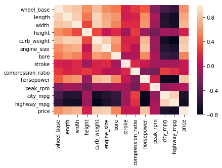

```python
# Mapa de correlação

sns.heatmap(df_automobile.corr())
```

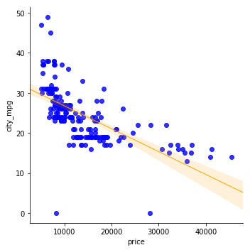

```python
# Preço por consumo em mpg (milhas por galão) na cidade
# Identifica que quanto menor é o consumo maior é o preço
sns.lmplot("price", "city_mpg", df_automobile,
          scatter_kws={"marker":"x", "color":"blue"},
          line_kws={"linewidth":1, "color": "orange"})
```

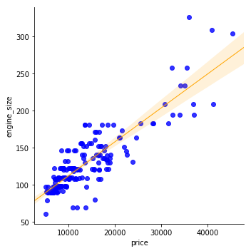

```python
# Preço po Tamanho do Motor
# Identifica que quanto maior é o motor maior é o preço
sns.lmplot("price", "engine_size", df_automobile,
          scatter_kws={"marker":"x", "color":"blue"},
          line_kws={"linewidth":1, "color": "orange"})
```

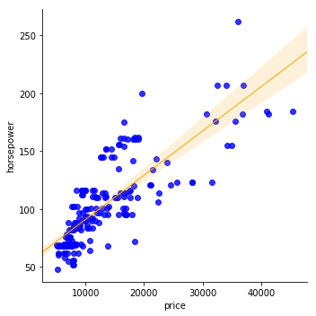

```python
# Preço por Força do Motor
# Quanto maior é a força maior é o preço
sns.lmplot("price", "horsepower", df_automobile,
          scatter_kws={"marker":"x", "color":"blue"},
          line_kws={"linewidth":1, "color": "orange"})
```

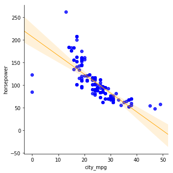

```python
# consumo em mpg (milhas por galão) na cidade por Força do motor
# Identifica que quanto menor é a força do motor maior é o consulmo na cidade.
sns.lmplot("city_mpg", "horsepower", df_automobile,
          scatter_kws={"marker":"x", "color":"blue"},
          line_kws={"linewidth":1, "color": "orange"})
```

**Pergunta:** Cite um exemplo de pelo menos os 3 cenários propostos que corroboram a leitura dos dados apresentados, justique sua resposta.

**Resposta:** O grafico **Preço por Força do Motor**, onde nota-se uma relação entre os campos "price" e "horsepower". NO gráfico nota-se a seguinte relação: quanto maior é a força do Motor, maior será o preço do carro.

## Preparação dos Dados

### Identificação de Outliers Visualmente

Utilize visualizações gráficas para encontrar outliers em todos os atributos deste dataset. Ainda não vamos remover ou atualizar os valores, por enquanto é uma análise exploratória.

Lembre-se que cada atributo possui um valor e dimensão diferente, portanto comparações devem estar em uma mesma base, por exemplo, **price** não pode ser comparado com **width** pois os eixos **y** estarão sem proporção.

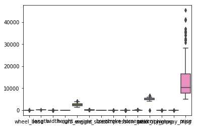

```python
#IMPLEMENTAÇÃO

sns.boxplot(data=df_automobile)
```

```python
#Função para normalizar os valores deixando na mesma faixa e podendo identificar com mais facilidade os outliers
def df_norm_valores(df, colunas):
    df_norm = df.copy()

    for coluna in colunas:
        df_norm[coluna] = df[coluna].div(df_norm[coluna].sum(), axis=0)

    return df_norm
```

```python
colunas = ["wheel_base", "length", "width", "height", "curb_weight", "engine_size", "bore",
           "stroke", "compression_ratio", "horsepower", "peak_rpm", "city_mpg", "highway_mpg", "price"]

df_automobile_norm = df_norm_valores(df_automobile, colunas)
df_automobile_norm.head(10)
```

|  | make | fuel_type | aspiration | number_of_doors | body_style | drive_wheels | engine_location | wheel_base | length | width | ... | engine_size | fuel_system | bore | stroke | compression_ratio | horsepower | peak_rpm | city_mpg | highway_mpg | price |
| --- | --- | --- | --- | --- | --- | --- | --- | --- | --- | --- | --- | --- | --- | --- | --- | --- | --- | --- | --- | --- | --- |
| 0 | alfa-romero | gas | std | two | convertible | rwd | front | 0.004462 | 0.004821 | 0.004840 | ... | 0.005098 | mpfi | 0.005185 | 0.004088 | 0.004405 | 0.005348 | 0.004963 | 0.004213 | 0.004420 | 0.005084 |
| 1 | alfa-romero | gas | std | two | convertible | rwd | front | 0.004462 | 0.004821 | 0.004840 | ... | 0.005098 | mpfi | 0.005185 | 0.004088 | 0.004405 | 0.005348 | 0.004963 | 0.004213 | 0.004420 | 0.006216 |
| 2 | alfa-romero | gas | std | two | hatchback | rwd | front | 0.004759 | 0.004889 | 0.004946 | ... | 0.005960 | mpfi | 0.004004 | 0.005293 | 0.004405 | 0.007420 | 0.004963 | 0.003811 | 0.004256 | 0.006216 |
| 3 | audi | gas | std | four | sedan | fwd | front | 0.005026 | 0.005044 | 0.004999 | ... | 0.004274 | mpfi | 0.004766 | 0.005186 | 0.004895 | 0.004914 | 0.005459 | 0.004814 | 0.004911 | 0.005255 |
| 4 | audi | gas | std | four | sedan | 4wd | front | 0.005005 | 0.005044 | 0.005014 | ... | 0.005333 | mpfi | 0.004766 | 0.005186 | 0.003916 | 0.005541 | 0.005459 | 0.003611 | 0.003601 | 0.006573 |
| 5 | audi | gas | std | two | sedan | fwd | front | 0.005026 | 0.005064 | 0.005006 | ... | 0.005333 | mpfi | 0.004766 | 0.005186 | 0.004161 | 0.005300 | 0.005459 | 0.003811 | 0.004092 | 0.005745 |
| 6 | audi | gas | std | four | sedan | fwd | front | 0.005328 | 0.005503 | 0.005391 | ... | 0.005333 | mpfi | 0.004766 | 0.005186 | 0.004161 | 0.005300 | 0.005459 | 0.003811 | 0.004092 | 0.006671 |
| 7 | audi | gas | std | four | wagon | fwd | front | 0.005328 | 0.005503 | 0.005391 | ... | 0.005333 | mpfi | 0.004766 | 0.005186 | 0.004161 | 0.005300 | 0.005459 | 0.003811 | 0.004092 | 0.007127 |
| 8 | audi | gas | turbo | four | sedan | fwd | front | 0.005328 | 0.005503 | 0.005391 | ... | 0.005137 | mpfi | 0.004677 | 0.005186 | 0.004063 | 0.006745 | 0.005459 | 0.003410 | 0.003274 | 0.008994 |
| 9 | bmw | gas | std | two | sedan | rwd | front | 0.005096 | 0.005049 | 0.004893 | ... | 0.004235 | mpfi | 0.005230 | 0.004271 | 0.004307 | 0.004866 | 0.005757 | 0.004614 | 0.004747 | 0.006189 |

10 rows × 24 columns

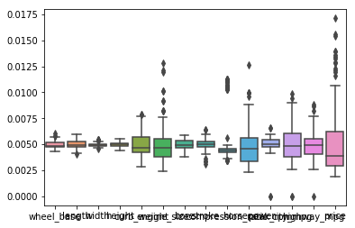

```python
sns.boxplot(data=df_automobile_norm)
```

Antes de explorar melhor as correlações, vamos analisar se há dados discrepante no conjunto de dados. Analisar os dados sem esta análise antes pode nos levar a algum viés indesejado.

### Análise de valores inválidos

Analise e busque por valores considerados nulos.

```python
#IMPLEMENTAÇÃO
df_automobile.isnull().any()
```

```
make                   False
fuel_type              False
aspiration             False
number_of_doors        False
body_style             False
drive_wheels           False
engine_location        False
wheel_base             False
length                 False
width                  False
height                 False
curb_weight            False
engine_type            False
number_of_cylinders    False
engine_size            False
fuel_system            False
bore                   False
stroke                 False
compression_ratio      False
horsepower             False
peak_rpm                True
city_mpg                True
highway_mpg             True
price                  False
dtype: bool
```

Para os dados considerados nulos, realize a imputação de dados utilizando um valor apropriado (note que pode haver dados paramétricos e dados numéricos). Justique sua resposta.

```python
df_automobile[df_automobile["peak_rpm"].isnull()]
```

|  | make | fuel_type | aspiration | number_of_doors | body_style | drive_wheels | engine_location | wheel_base | length | width | ... | engine_size | fuel_system | bore | stroke | compression_ratio | horsepower | peak_rpm | city_mpg | highway_mpg | price |
| --- | --- | --- | --- | --- | --- | --- | --- | --- | --- | --- | --- | --- | --- | --- | --- | --- | --- | --- | --- | --- | --- |
| 136 | subaru | gas | std | two | hatchback | 4wd | front | 93.3 | 157.3 | 63.8 | ... | 108 | 2bbl | 3.62 | 2.64 | 8.7 | 73 | NaN | 26.0 | 31.0 | 7603 |
| 184 | volkswagen | gas | std | four | sedan | fwd | front | 97.3 | 171.7 | 65.5 | ... | 109 | mpfi | 3.19 | 3.40 | 10.0 | 100 | NaN | 26.0 | 32.0 | 9995 |

2 rows × 24 columns

```python
df_automobile[df_automobile["city_mpg"].isnull()]
```

|  | make | fuel_type | aspiration | number_of_doors | body_style | drive_wheels | engine_location | wheel_base | length | width | ... | engine_size | fuel_system | bore | stroke | compression_ratio | horsepower | peak_rpm | city_mpg | highway_mpg | price |
| --- | --- | --- | --- | --- | --- | --- | --- | --- | --- | --- | --- | --- | --- | --- | --- | --- | --- | --- | --- | --- | --- |
| 36 | honda | gas | std | two | hatchback | fwd | front | 96.5 | 167.5 | 65.2 | ... | 110 | 1bbl | 3.15 | 3.58 | 9.0 | 86 | 5800.0 | NaN | 33.0 | 7895 |

1 rows × 24 columns

```python
df_automobile[df_automobile["highway_mpg"].isnull()]
```

|  | make | fuel_type | aspiration | number_of_doors | body_style | drive_wheels | engine_location | wheel_base | length | width | ... | engine_size | fuel_system | bore | stroke | compression_ratio | horsepower | peak_rpm | city_mpg | highway_mpg | price |
| --- | --- | --- | --- | --- | --- | --- | --- | --- | --- | --- | --- | --- | --- | --- | --- | --- | --- | --- | --- | --- | --- |
| 32 | honda | gas | std | two | hatchback | fwd | front | 93.7 | 150.0 | 64.0 | ... | 92 | 1bbl | 2.91 | 3.41 | 9.2 | 76 | 0.0 | 30.0 | NaN | 6529 |

1 rows × 24 columns

```python
#IMPLEMENTAÇÃO
# Incluir o tratamento dos dados nulos
# Alteração dos valores para zero 0

df_automobile["peak_rpm"]    = df_automobile["peak_rpm"].replace(np.nan, 0)
df_automobile["city_mpg"]    = df_automobile["city_mpg"].replace(np.nan, 0)
df_automobile["highway_mpg"] = df_automobile["highway_mpg"].replace(np.nan, 0)

df_automobile.isnull().any()
```

```
make                   False
fuel_type              False
aspiration             False
number_of_doors        False
body_style             False
drive_wheels           False
engine_location        False
wheel_base             False
length                 False
width                  False
height                 False
curb_weight            False
engine_type            False
number_of_cylinders    False
engine_size            False
fuel_system            False
bore                   False
stroke                 False
compression_ratio      False
horsepower             False
peak_rpm               False
city_mpg               False
highway_mpg            False
price                  False
dtype: bool
```

### Análise de valores com valores iguais a 0

Analise se no conjunto de dados há valores iguais a 0 e verifique se faz parte do contexto. Caso não faça parte do contexto, utilize alguma técnica de imputação de dados apropriada.

Inspecione o dataset por dados iguais a 0.

```python
#IMPLEMENTAÇÃO

(df_automobile == 0).any()
```

```
make                   False
fuel_type              False
aspiration             False
number_of_doors        False
body_style             False
drive_wheels           False
engine_location        False
wheel_base             False
length                 False
width                  False
height                 False
curb_weight            False
engine_type            False
number_of_cylinders    False
engine_size            False
fuel_system            False
bore                   False
stroke                 False
compression_ratio      False
horsepower             False
peak_rpm                True
city_mpg                True
highway_mpg             True
price                  False
dtype: bool
```

A imputação de dados pode seguir algum padrão dos demais exemplos ou pode ser simplesmente atribuído um valor. Avalie tais condições de acordo com as inspeções de dados.

```python
df_automobile[df_automobile["peak_rpm"] == 0]
```

|  | make | fuel_type | aspiration | number_of_doors | body_style | drive_wheels | engine_location | wheel_base | length | width | ... | engine_size | fuel_system | bore | stroke | compression_ratio | horsepower | peak_rpm | city_mpg | highway_mpg | price |
| --- | --- | --- | --- | --- | --- | --- | --- | --- | --- | --- | --- | --- | --- | --- | --- | --- | --- | --- | --- | --- | --- |
| 32 | honda | gas | std | two | hatchback | fwd | front | 93.7 | 150.0 | 64.0 | ... | 92 | 1bbl | 2.91 | 3.41 | 9.2 | 76 | 0.0 | 30.0 | 0.0 | 6529 |
| 35 | honda | gas | std | four | wagon | fwd | front | 96.5 | 157.1 | 63.9 | ... | 92 | 1bbl | 2.92 | 3.41 | 9.2 | 76 | 0.0 | 30.0 | 34.0 | 7295 |
| 136 | subaru | gas | std | two | hatchback | 4wd | front | 93.3 | 157.3 | 63.8 | ... | 108 | 2bbl | 3.62 | 2.64 | 8.7 | 73 | 0.0 | 26.0 | 31.0 | 7603 |
| 184 | volkswagen | gas | std | four | sedan | fwd | front | 97.3 | 171.7 | 65.5 | ... | 109 | mpfi | 3.19 | 3.40 | 10.0 | 100 | 0.0 | 26.0 | 32.0 | 9995 |

4 rows × 24 columns

```python
df_automobile[df_automobile["city_mpg"] == 0]
```

|  | make | fuel_type | aspiration | number_of_doors | body_style | drive_wheels | engine_location | wheel_base | length | width | ... | engine_size | fuel_system | bore | stroke | compression_ratio | horsepower | peak_rpm | city_mpg | highway_mpg | price |
| --- | --- | --- | --- | --- | --- | --- | --- | --- | --- | --- | --- | --- | --- | --- | --- | --- | --- | --- | --- | --- | --- |
| 36 | honda | gas | std | two | hatchback | fwd | front | 96.5 | 167.5 | 65.2 | ... | 110 | 1bbl | 3.15 | 3.58 | 9.0 | 86 | 5800.0 | 0.0 | 33.0 | 7895 |
| 66 | mercedes-benz | diesel | turbo | two | hardtop | rwd | front | 106.7 | 187.5 | 70.3 | ... | 183 | idi | 3.58 | 3.64 | 21.5 | 123 | 4350.0 | 0.0 | 25.0 | 28176 |
| 181 | volkswagen | gas | std | four | sedan | fwd | front | 97.3 | 171.7 | 65.5 | ... | 109 | mpfi | 3.19 | 3.40 | 9.0 | 85 | 5250.0 | 0.0 | 34.0 | 8195 |

3 rows × 24 columns

```python
df_automobile[df_automobile["highway_mpg"] == 0]
```

|  | make | fuel_type | aspiration | number_of_doors | body_style | drive_wheels | engine_location | wheel_base | length | width | ... | engine_size | fuel_system | bore | stroke | compression_ratio | horsepower | peak_rpm | city_mpg | highway_mpg | price |
| --- | --- | --- | --- | --- | --- | --- | --- | --- | --- | --- | --- | --- | --- | --- | --- | --- | --- | --- | --- | --- | --- |
| 32 | honda | gas | std | two | hatchback | fwd | front | 93.7 | 150.0 | 64.0 | ... | 92 | 1bbl | 2.91 | 3.41 | 9.2 | 76 | 0.0 | 30.0 | 0.0 | 6529 |
| 67 | mercedes-benz | diesel | turbo | four | sedan | rwd | front | 115.6 | 202.6 | 71.7 | ... | 183 | idi | 3.58 | 3.64 | 21.5 | 123 | 4350.0 | 22.0 | 0.0 | 31600 |

2 rows × 24 columns

```python
#IMPLEMENTAR
# Verificação de valores com Zero no Dataframe
# Primeiramente encontrar as colunas que contem campos Zerados
serie_coluna = df_automobile.isin([0]).any()
serie_coluna = serie_coluna[serie_coluna == True]

# Então, recupera o media por make e atribui o valor ao campo zerado
for i, v in serie_coluna.items():
    df_automobile_serie = df_automobile[ df_automobile[i] == 0 ]
    for make in df_automobile_serie["make"]:
        nonzero_mean = df_automobile[ ( df_automobile[i] != 0) & ( df_automobile["make"] == make)][i].mean()
        df_automobile.loc[(df_automobile[i] == 0) & (df_automobile["make"] == make), i ] = nonzero_mean

df_automobile.isin([0]).any()
```

```
make                   False
fuel_type              False
aspiration             False
number_of_doors        False
body_style             False
drive_wheels           False
engine_location        False
wheel_base             False
length                 False
width                  False
height                 False
curb_weight            False
engine_type            False
number_of_cylinders    False
engine_size            False
fuel_system            False
bore                   False
stroke                 False
compression_ratio      False
horsepower             False
peak_rpm               False
city_mpg               False
highway_mpg            False
price                  False
dtype: bool
```

### Análise Numérica de Outliers

Da análise visual de outliers realizada acima vamos utilizar uma métrica de verificação mais apropriada e objetiva afim de criar um patamar aceitável de dados não discrepantes.

Neste projeto vamos considerar [o Método Turco para identificar discrepantes](http://datapigtechnologies.com/blog/index.php/highlighting-outliers-in-your-data-with-the-tukey-method/), que utiliza um **passo de limite** que é 5 vezes (em nosso projeto) a diferença entre o terceiro (Q3) e o primeiro quartil (Q1). Deste modo, valores que sejam maiores que o Q3 + passo de limite ou menor Q2 - passo de limite sejam sinalizados como outliers.

Construa uma função que receba como parâmetro de entrada um série de dados e exiba os valores discrepantes. Utilize o boilerplate abaixo para completar as instruções faltantes.

*Dica: utilize a função do Numpy de percentil, np.percentile(serie, 25) para quartil 1 e np.percentile(serie, 75) para quartil 3.*

```python
def identificacao_outlier(df, column_name):
    #IMPLEMENTAÇÃO
    print("Coluna : " + column_name)

    Q1 = np.percentile(df[column_name], 25)
    Q3 = np.percentile(df[column_name], 75)

    passo_de_limite = (Q3 - Q1) * 5

    outlier_lower = (Q1 - passo_de_limite)
    outlier_upper = (Q3 + passo_de_limite)

    print("Outliear menor que : {0:0.2f}".format(round((outlier_lower),2)) + " - Quantidade : " +
              str(df[df[column_name] < outlier_lower][column_name].count()))
    print("Outliear maior que : " + str(outlier_upper) + " - Quantidade : " +
              str(df[df[column_name] > outlier_upper][column_name].count()))
    print("")
```

```python
series = ["wheel_base", "length", "width", "height", "curb_weight", "engine_size", "bore",
           "stroke", "compression_ratio", "horsepower", "peak_rpm", "city_mpg", "highway_mpg", "price"]

for iSerie in series:
    identificacao_outlier(df_automobile, iSerie)
```

```
Coluna : wheel_base
Outliear menor que : 55.00 - Quantidade : 0
Outliear maior que : 141.90000000000003 - Quantidade : 0

Coluna : length
Outliear menor que : 83.30 - Quantidade : 0
Outliear maior que : 266.99999999999994 - Quantidade : 0

Coluna : width
Outliear menor que : 51.60 - Quantidade : 0
Outliear maior que : 79.1 - Quantidade : 0

Coluna : height
Outliear menor que : 34.50 - Quantidade : 0
Outliear maior que : 73.0 - Quantidade : 0

Coluna : curb_weight
Outliear menor que : -1616.00 - Quantidade : 0
Outliear maior que : 6711.0 - Quantidade : 0

Coluna : engine_size
Outliear menor que : -117.00 - Quantidade : 0
Outliear maior que : 356.0 - Quantidade : 0

Coluna : bore
Outliear menor que : 1.00 - Quantidade : 0
Outliear maior que : 5.73 - Quantidade : 0

Coluna : stroke
Outliear menor que : 1.36 - Quantidade : 0
Outliear maior que : 5.210000000000001 - Quantidade : 0

Coluna : compression_ratio
Outliear menor que : 4.60 - Quantidade : 0
Outliear maior que : 13.400000000000004 - Quantidade : 20

Coluna : horsepower
Outliear menor que : -160.00 - Quantidade : 0
Outliear maior que : 346.0 - Quantidade : 0

Coluna : peak_rpm
Outliear menor que : 1300.00 - Quantidade : 0
Outliear maior que : 9000.0 - Quantidade : 0

Coluna : city_mpg
Outliear menor que : -36.00 - Quantidade : 0
Outliear maior que : 85.0 - Quantidade : 0

Coluna : highway_mpg
Outliear menor que : -20.00 - Quantidade : 0
Outliear maior que : 79.0 - Quantidade : 0

Coluna : price
Outliear menor que : -35850.00 - Quantidade : 0
Outliear maior que : 60125.0 - Quantidade : 0
```

```python
column_name = "compression_ratio"
outlier_upper = 13.4
df_automobile[df_automobile[column_name] < outlier_upper][column_name].describe()
```

```
count    181.000000
mean       8.855912
std        0.674151
min        7.000000
25%        8.500000
50%        9.000000
75%        9.400000
max       11.500000
Name: compression_ratio, dtype: float64
```

```python
df_automobile[column_name].describe()
```

```
count    201.000000
mean      10.164279
std        4.004965
min        7.000000
25%        8.600000
50%        9.000000
75%        9.400000
max       23.000000
Name: compression_ratio, dtype: float64
```

```python
df_automobile[df_automobile[column_name] > outlier_upper]
```

|  | make | fuel_type | aspiration | number_of_doors | body_style | drive_wheels | engine_location | wheel_base | length | width | ... | engine_size | fuel_system | bore | stroke | compression_ratio | horsepower | peak_rpm | city_mpg | highway_mpg | price |
| --- | --- | --- | --- | --- | --- | --- | --- | --- | --- | --- | --- | --- | --- | --- | --- | --- | --- | --- | --- | --- | --- |
| 60 | mazda | diesel | std | four | sedan | fwd | front | 98.8 | 177.8 | 66.5 | ... | 122 | idi | 3.39 | 3.39 | 22.7 | 64 | 4650.0 | 36.0 | 42.000000 | 10795 |
| 63 | mazda | diesel | std | four | sedan | rwd | front | 104.9 | 175.0 | 66.1 | ... | 134 | idi | 3.43 | 3.64 | 22.0 | 72 | 4200.0 | 31.0 | 39.000000 | 18344 |
| 64 | mercedes-benz | diesel | turbo | four | sedan | rwd | front | 110.0 | 190.9 | 70.3 | ... | 183 | idi | 3.58 | 3.64 | 21.5 | 123 | 4350.0 | 22.0 | 25.000000 | 25552 |
| 65 | mercedes-benz | diesel | turbo | four | wagon | rwd | front | 110.0 | 190.9 | 70.3 | ... | 183 | idi | 3.58 | 3.64 | 21.5 | 123 | 4350.0 | 22.0 | 25.000000 | 28248 |
| 66 | mercedes-benz | diesel | turbo | two | hardtop | rwd | front | 106.7 | 187.5 | 70.3 | ... | 183 | idi | 3.58 | 3.64 | 21.5 | 123 | 4350.0 | 18.0 | 25.000000 | 28176 |
| 67 | mercedes-benz | diesel | turbo | four | sedan | rwd | front | 115.6 | 202.6 | 71.7 | ... | 183 | idi | 3.58 | 3.64 | 21.5 | 123 | 4350.0 | 22.0 | 20.428571 | 31600 |
| 87 | nissan | diesel | std | two | sedan | fwd | front | 94.5 | 165.3 | 63.8 | ... | 103 | idi | 2.99 | 3.47 | 21.9 | 55 | 4800.0 | 45.0 | 50.000000 | 7099 |
| 105 | peugot | diesel | turbo | four | sedan | rwd | front | 107.9 | 186.7 | 68.4 | ... | 152 | idi | 3.70 | 3.52 | 21.0 | 95 | 4150.0 | 28.0 | 33.000000 | 13200 |
| 107 | peugot | diesel | turbo | four | wagon | rwd | front | 114.2 | 198.9 | 68.4 | ... | 152 | idi | 3.70 | 3.52 | 21.0 | 95 | 4150.0 | 25.0 | 25.000000 | 13860 |
| 109 | peugot | diesel | turbo | four | sedan | rwd | front | 107.9 | 186.7 | 68.4 | ... | 152 | idi | 3.70 | 3.52 | 21.0 | 95 | 4150.0 | 28.0 | 33.000000 | 16900 |
| 111 | peugot | diesel | turbo | four | wagon | rwd | front | 114.2 | 198.9 | 68.4 | ... | 152 | idi | 3.70 | 3.52 | 21.0 | 95 | 4150.0 | 25.0 | 25.000000 | 17075 |
| 113 | peugot | diesel | turbo | four | sedan | rwd | front | 107.9 | 186.7 | 68.4 | ... | 152 | idi | 3.70 | 3.52 | 21.0 | 95 | 4150.0 | 28.0 | 33.000000 | 17950 |
| 154 | toyota | diesel | std | four | sedan | fwd | front | 95.7 | 166.3 | 64.4 | ... | 110 | idi | 3.27 | 3.35 | 22.5 | 56 | 4500.0 | 34.0 | 36.000000 | 7898 |
| 155 | toyota | diesel | std | four | hatchback | fwd | front | 95.7 | 166.3 | 64.4 | ... | 110 | idi | 3.27 | 3.35 | 22.5 | 56 | 4500.0 | 38.0 | 47.000000 | 7788 |
| 170 | toyota | diesel | turbo | four | sedan | fwd | front | 102.4 | 175.6 | 66.5 | ... | 110 | idi | 3.27 | 3.35 | 22.5 | 73 | 4500.0 | 30.0 | 33.000000 | 10698 |
| 178 | volkswagen | diesel | std | two | sedan | fwd | front | 97.3 | 171.7 | 65.5 | ... | 97 | idi | 3.01 | 3.40 | 23.0 | 52 | 4800.0 | 37.0 | 46.000000 | 7775 |
| 180 | volkswagen | diesel | std | four | sedan | fwd | front | 97.3 | 171.7 | 65.5 | ... | 97 | idi | 3.01 | 3.40 | 23.0 | 52 | 4800.0 | 37.0 | 46.000000 | 7995 |
| 183 | volkswagen | diesel | turbo | four | sedan | fwd | front | 97.3 | 171.7 | 65.5 | ... | 97 | idi | 3.01 | 3.40 | 23.0 | 68 | 4500.0 | 37.0 | 42.000000 | 9495 |
| 188 | volkswagen | diesel | turbo | four | sedan | fwd | front | 100.4 | 180.2 | 66.9 | ... | 97 | idi | 3.01 | 3.40 | 23.0 | 68 | 4500.0 | 33.0 | 38.000000 | 13845 |
| 199 | volvo | diesel | turbo | four | sedan | rwd | front | 109.1 | 188.8 | 68.9 | ... | 145 | idi | 3.01 | 3.40 | 23.0 | 106 | 4800.0 | 26.0 | 27.000000 | 22470 |

20 rows × 24 columns

**Pergunta:** Houve dados discrepantes localizados pela metodologia sugerida? Quais foram os atributos discrepantes e quais as hipótese de serem discrepantes? Qual foi a sua conclusão, são realmente dados que devem ser removidos ou mantidos? Justifique.

**Resposta:** Sim, o atribudo discrepante identificado é **"compression_ratio"**. Manteremos os resgistro devido ao tamanho da base ser cerca de 10% do tamanho da base e com isso manteremos uma maior variabilidade de observações.

### Mapeamento de Dados Paramétricos

Os algoritmos de aprendizado de máquina precisam receber dados que sejam inteiramente numéricos. Dados que representam uma classificação como por exemplo um tipo de carro, como sedan ou hatchback, deve ser convertido em um valor numérico associado, como por exemplo 1 ou 2.

Crie uma função que receba uma lista única e retorne um dicionário com a categoria e um código numérico crescente e incremental para posteriormente utilizarmos como mapeamento.

```python
#IMPLEMENTAÇÃO

def mapear_serie(serie):
    dict_gen = {}
    objuniqueSerie = serie.unique()
    numerico_serie = 1
    mapeamento_serie = ""

    #IMPLEMENTAÇÃO
    for x in objuniqueSerie:
        mapeamento_serie += '"' + str(x) +  '": ' + str(numerico_serie) + ','
        numerico_serie += 1

    # Cast do tipo string para Dict utilizando a função Loads do json
    dict_gen = json.loads('{' + mapeamento_serie[:-1] + '}')

    return dict_gen
```

Com a funcão criada, crie dicionários para cada coluna paramétrica. Lembre-se que é necessário passar somente valores únicos.

*Dica: utilize a função unique() do dataframe para obter valores únicos de uma determinada série (ou coluna).*

```python
# IMPLEMENTAÇÃO
series = ["make","fuel_type", "aspiration", "number_of_doors","body_style","drive_wheels","engine_location","fuel_system",
          "engine_type","number_of_cylinders"]

# Criando uma copy do Data Frame principal
df_automobile_maped = df_automobile.copy()

for iSerie in series:
    # Criando os discionarios das colunas não númericas
    mapeamento_serie = mapear_serie(df_automobile[iSerie])
    print(iSerie)
    print(mapeamento_serie)
    print("")

    # Mapeamento das colunas com informação não númericas
    df_automobile_maped[iSerie] = df_automobile_maped[iSerie].map(mapeamento_serie)
```

[output not shown]

Até este momento seu conjunto de dados não deve conter nenhum dado paramétrico. Todos os dados armazenados com valores como texto, por exemplo, "diese", "gas" deve estar preenchido com valores numéricos, como 1 ou 2.

Inspecione seus dados e certifique de que tudo está certo.

*Dica: utilize uma inspeção simples visual, com 20 amostras.*

```python
#IMPLEMENTAÇÃO
df_automobile_maped.head(20)
```

|  | make | fuel_type | aspiration | number_of_doors | body_style | drive_wheels | engine_location | wheel_base | length | width | ... | engine_size | fuel_system | bore | stroke | compression_ratio | horsepower | peak_rpm | city_mpg | highway_mpg | price |
| --- | --- | --- | --- | --- | --- | --- | --- | --- | --- | --- | --- | --- | --- | --- | --- | --- | --- | --- | --- | --- | --- |
| 0 | 1 | 1 | 1 | 1 | 1 | 1 | 1 | 88.6 | 168.8 | 64.1 | ... | 130 | 1 | 3.47 | 2.68 | 9.0 | 111 | 5000.0 | 21.0 | 27.0 | 13495 |
| 1 | 1 | 1 | 1 | 1 | 1 | 1 | 1 | 88.6 | 168.8 | 64.1 | ... | 130 | 1 | 3.47 | 2.68 | 9.0 | 111 | 5000.0 | 21.0 | 27.0 | 16500 |
| 2 | 1 | 1 | 1 | 1 | 2 | 1 | 1 | 94.5 | 171.2 | 65.5 | ... | 152 | 1 | 2.68 | 3.47 | 9.0 | 154 | 5000.0 | 19.0 | 26.0 | 16500 |
| 3 | 2 | 1 | 1 | 2 | 3 | 2 | 1 | 99.8 | 176.6 | 66.2 | ... | 109 | 1 | 3.19 | 3.40 | 10.0 | 102 | 5500.0 | 24.0 | 30.0 | 13950 |
| 4 | 2 | 1 | 1 | 2 | 3 | 3 | 1 | 99.4 | 176.6 | 66.4 | ... | 136 | 1 | 3.19 | 3.40 | 8.0 | 115 | 5500.0 | 18.0 | 22.0 | 17450 |
| 5 | 2 | 1 | 1 | 1 | 3 | 2 | 1 | 99.8 | 177.3 | 66.3 | ... | 136 | 1 | 3.19 | 3.40 | 8.5 | 110 | 5500.0 | 19.0 | 25.0 | 15250 |
| 6 | 2 | 1 | 1 | 2 | 3 | 2 | 1 | 105.8 | 192.7 | 71.4 | ... | 136 | 1 | 3.19 | 3.40 | 8.5 | 110 | 5500.0 | 19.0 | 25.0 | 17710 |
| 7 | 2 | 1 | 1 | 2 | 4 | 2 | 1 | 105.8 | 192.7 | 71.4 | ... | 136 | 1 | 3.19 | 3.40 | 8.5 | 110 | 5500.0 | 19.0 | 25.0 | 18920 |
| 8 | 2 | 1 | 2 | 2 | 3 | 2 | 1 | 105.8 | 192.7 | 71.4 | ... | 131 | 1 | 3.13 | 3.40 | 8.3 | 140 | 5500.0 | 17.0 | 20.0 | 23875 |
| 9 | 3 | 1 | 1 | 1 | 3 | 1 | 1 | 101.2 | 176.8 | 64.8 | ... | 108 | 1 | 3.50 | 2.80 | 8.8 | 101 | 5800.0 | 23.0 | 29.0 | 16430 |
| 10 | 3 | 1 | 1 | 2 | 3 | 1 | 1 | 101.2 | 176.8 | 64.8 | ... | 108 | 1 | 3.50 | 2.80 | 8.8 | 101 | 5800.0 | 23.0 | 29.0 | 16925 |
| 11 | 3 | 1 | 1 | 1 | 3 | 1 | 1 | 101.2 | 176.8 | 64.8 | ... | 164 | 1 | 3.31 | 3.19 | 9.0 | 121 | 4250.0 | 21.0 | 28.0 | 20970 |
| 12 | 3 | 1 | 1 | 2 | 3 | 1 | 1 | 101.2 | 176.8 | 64.8 | ... | 164 | 1 | 3.31 | 3.19 | 9.0 | 121 | 4250.0 | 21.0 | 28.0 | 21105 |
| 13 | 3 | 1 | 1 | 2 | 3 | 1 | 1 | 103.5 | 189.0 | 66.9 | ... | 164 | 1 | 3.31 | 3.19 | 9.0 | 121 | 4250.0 | 20.0 | 25.0 | 24565 |
| 14 | 3 | 1 | 1 | 2 | 3 | 1 | 1 | 103.5 | 189.0 | 66.9 | ... | 209 | 1 | 3.62 | 3.39 | 8.0 | 182 | 5400.0 | 16.0 | 22.0 | 30760 |
| 15 | 3 | 1 | 1 | 1 | 3 | 1 | 1 | 103.5 | 193.8 | 67.9 | ... | 209 | 1 | 3.62 | 3.39 | 8.0 | 182 | 5400.0 | 16.0 | 22.0 | 41315 |
| 16 | 3 | 1 | 1 | 2 | 3 | 1 | 1 | 110.0 | 197.0 | 70.9 | ... | 209 | 1 | 3.62 | 3.39 | 8.0 | 182 | 5400.0 | 15.0 | 20.0 | 36880 |
| 17 | 4 | 1 | 1 | 1 | 2 | 2 | 1 | 88.4 | 141.1 | 60.3 | ... | 61 | 2 | 2.91 | 3.03 | 9.5 | 48 | 5100.0 | 47.0 | 53.0 | 5151 |
| 18 | 4 | 1 | 1 | 1 | 2 | 2 | 1 | 94.5 | 155.9 | 63.6 | ... | 90 | 2 | 3.03 | 3.11 | 9.6 | 70 | 5400.0 | 38.0 | 43.0 | 6295 |
| 19 | 4 | 1 | 1 | 2 | 3 | 2 | 1 | 94.5 | 158.8 | 63.6 | ... | 90 | 2 | 3.03 | 3.11 | 9.6 | 70 | 5400.0 | 38.0 | 43.0 | 6575 |

20 rows × 24 columns

## Desenvolvimento do Modelo

O conjunto de dados que temos a nossa disposição indica a aplicação de um modelo voltado a regressão, ou seja, queremos prever um preço de um veículo dada certas condições. É um problema típico de predição de série numérica.

Podemos aplicar quaisquer algoritmos de regressão existente que tenha aplicação de classificação, pois é de um domínio diferente.

Iremos explorar 3 modelos de algoritmos de regressão para testar a performance de cada um deles. Ao final será eleito o que apresentar melhor performance de pontuação R².

Os algoritmos são:

1. [Regressão Linear](http://scikit-learn.org/stable/auto_examples/linear_model/plot_ols.html)
2. [Regressão de Árvore de Decisão](http://scikit-learn.org/stable/modules/generated/sklearn.tree.DecisionTreeRegressor.html)
3. [Regressão Ridge](http://scikit-learn.org/stable/modules/linear_model.html#ridge-regression)

**Pergunta:** Explique como cada modelo de regressão funciona, indicando pelo menos um caso de uso em cada um deles.

**Resposta:**

> **"Modelo de Regressão Linear:"** A regressão linear é chamada "linear" porque se considera que a relação da resposta às variáveis é uma função linear de alguns parâmetros. Os modelos de regressão que não são uma função linear dos parâmetros se chamam modelos de regressão não-linear. Sendo uma das primeiras formas de análise regressiva a ser estudada rigorosamente, e usada extensamente em aplicações práticas. Isso acontece porque modelos que dependem de forma linear dos seus parâmetros desconhecidos, são mais fáceis de ajustar que os modelos não-lineares aos seus parâmetros, e porque as propriedades estatísticas dos estimadores resultantes são fáceis de determinar. Modelos de regressão linear são frequentemente ajustados usando a abordagem dos mínimos quadrados, mas que também pode ser montada de outras maneiras, tal como minimizando a "falta de ajuste" em alguma outra norma (com menos desvios absolutos de regressão), ou através da minimização de uma penalização da versão dos mínimos quadrados. Por outro lado, a abordagem de mínimos quadrados pode ser utilizado para ajustar a modelos que não são modelos lineares. Assim, embora os termos "mínimos quadrados" e "modelo linear" estejam intimamente ligados, eles não são sinônimos.

> **"Modelo de Árvore de Decisão:"** O modelo de Árvore de Decisão é uma representação de uma tabela de decisão sob a forma de uma árvore, porém pode haver outras aplicações. Tem a mesma utilidade da tabela de decisão. Trata-se de uma maneira alternativa de expressar as mesmas regras que são obtidas quando se constrói a tabela. É uma abordagem comportamental que usa diagramas para mapear as varias alternativas e resultados de decisões de investimento, assim como as probabilidades de ocorrerem. Baseia - se em estimativas e probabilidades associadas aos resultados de cursos de ação que competem entre si. O resultado de cada curso de ação é ponderado pela probabilidade associada a ele; o resultado ponderado é somado e o valor esperado de cada curso de ação é, então determinado. A alternativa que proporciona o valor esperado mais alto é preferível. Essencialmente, árvores de decisões são diagramas que permitem representar e avaliar problemas que envolvem decisões sequenciais, colocando em destaque os riscos e os resultados financeiros identificados nos diversos cursos de ação. Para efectuar a representação gráfica da árvore de decisão são geralmente usadas linhas para identificar a decisão (por exemplo “sim” ou “não”) e nós para identificar a as questões sobre as quais se deve decidir. Cada um dos ramos formado por linhas e nós termina numa espécie de folha que identifica a consequência mais provável da sequência de decisões tomadas.

> **"Modelo de Regressão Ridge:"** O Modelo de Regressão Ridge é um método de regularização do modelo que tem como principal objetivo suavizar atributos que sejam relacionados uns aos outros e que aumentam o ruído no modelo (A.K.A multicolinearidade). Com isso com a retirada de determinados atributos do modelo, o mesmo converge para um resultado muito mais estável em que com a redução desses atributos, a redução em termos de acuácia do modelo se mantêm inalterada. O mecanismo algoritmico que faz isso é através de um mecanismo de penalização que coloca um viés e que vai reduzindo os valores os betas até não zero. Com isso os atributos que contribuem menos para o poder preditivo do modelo são levados para a irrelevância usando esse mecanismo de penalização do viés.

Antes de partimos para o treinamento do modelo, precisaremos separar os dados em subconjuntos para permitir avaliar adequadamente o modelo.

Uma boa razão de tamanho de conjunto de treinamento e testes é 80% e 20% ou ainda, 70% e 30%. O importante é não misturar dados de treinamento com os de teste para termos uma ideia melhor sobre a performance do modelo com dados previametne não treinados.

Antes de separarmos os dados, a partir das análises realizadas anteriormente, quais seriam os atributos a serem utilizados e por qual motivo. Informe também qual seria o atributo preditor?

```python
#IMPLEMENTAÇÃO
#
#1. make: fabricante
#2. fuel_type: tipo de combustível
#3. aspiration: tipo de aspiração do motor, ex. turbo ou padrão (std)
#4. number_of_doors: número de porta do Carro, ex. 2 ou 4 *
#5. body_style: estilo do carro, ex. sedan ou hatchback
#13. engine_type: tipo do motor
#16. fuel_system: sistema de injeção
#20. horsepower: cavalo de força ou HP
#22. city_mpg: consumo em mpg (milhas por galão) na cidade
#24. price: preço (**Variável Alvo**)

feature_col_names = ['make', 'fuel_type', 'aspiration', 'number_of_doors', 'body_style', 'engine_type',
                     'fuel_system', 'horsepower', 'city_mpg']
predicted_class_names = ['price']
```

Crie subsets de treinamento e teste utilizado uma razão adequada de tamanho. Utilze o `train_test_split` passando como parâmetros

```python
from sklearn.model_selection import train_test_split

#IMPLEMENTAÇÃO
X = df_automobile_maped[feature_col_names].values
y = df_automobile_maped[predicted_class_names].values

# Será utilizado o tamanho de 70% Treinamento e 30% Teste
split_test_size = 0.30

X_train, X_test, y_train, y_test = train_test_split(X, y, test_size=split_test_size, random_state=42)
```

Inspecione cada subconjunto de dados obtidos do `train_test_split`. Note que nos conjuntos X devemos ter atributos, logo é esperado uma matriz com mais de uma coluna. Nos conjuntos y, é a classe de predição, logo é esperado apenas um atributo.

```python
#IMPLEMENTAÇÃO
#Inspeção de X_train

len_X = len(X)
len_X_train =  len(X_train)
len_X_test = len(X_test)

valor_len_X_train = (len_X_train * 0.7)
valor_len_X_test = (len_X_test * 0.3)

print("Valor Total X : %s " %(len_X))
print("Valor Treino X: %s " %(len_X_train))
print("Valor Teste X : %s " %(len_X_test))
```

```
Valor Total X : 201
Valor Treino X: 140
Valor Teste X : 61
```

```python
#IMPLEMENTAÇÃO
#Inspeção de Y_train

len_y = len(y)
len_y_train =  len(y_train)
len_y_test = len(y_test)

valor_len_y_train = (len_y_train * 0.7)
valor_len_y_test = (len_y_test * 0.3)

print("Valor Total y : %s " %(len_y))
print("Valor Treino y: %s " %(len_y_train))
print("Valor Teste y : %s " %(len_y_test))
```

```
Valor Total y : 201
Valor Treino y: 140
Valor Teste y : 61
```

Verifique também se a razão dos conjuntos está coerente com a divisão estabelecida. Para estes cálculos divia o número de itens do conjunto de treino pelo total e também o de testes pelo total.

```python
#IMPLEMENTAÇÃO
valor_coerencia_train = (len_X_train / len_X)
valor_coerencia_test  = (len_X_test / len_X)

print("Valor de Coerencia Treino: {0:0.2f}%".format(round((valor_coerencia_train * 100),3)))
print("Valor de Coerencia Teste : {0:0.2f}%".format(round((valor_coerencia_test * 100) ,3)))
```

```
Valor de Coerencia Treino: 69.65%
Valor de Coerencia Teste : 30.35%
```

## Treinamento e teste do modelo

Após separarmos os dados adequadamente, selecionar os atributos que irão compor como o modelo deve treinar e qual atributo deve perseguir, o próximo passo é treinar este modelo e verificar, pelos testes, sua performance.

Este estudo também irá levar a escolhermos qual algoritmo devemos utilizar dentre os três selecionados neste ajuste.

Para avaliarmos a performance dos modelos, vamos criar uma função que determinará a pontuação R2.

Não esqueça de avaliar os conjuntos de dados de treino (`X_train`, `y_train` e de teste, `X_test` e `y_test`)

```python
from sklearn.metrics import mean_squared_error, r2_score
from time import time

def pontuacao(modelo, X_test, y_test):
    y_pred = modelo.predict(X_test)

    print("%s R2 score: %.2f" %(modelo,r2_score(y_test, y_pred)))

    return r2_score(y_test, y_pred)
```

### Regressão Linear

Utilize para a variável preditora a função `.ravel()` para converter os dados no formato que o `sklearn` espera.

```python
#IMPLEMENTAÇÃO
from sklearn import linear_model
lr_model = linear_model.LinearRegression()

start_RegressãoLinear_train = time()

# Conjunto de dados de Treinamento
lr_model.fit(X_train, y_train.ravel())

print("Tempo de Treinamento (Regressão Linear):", round(time()-start_RegressãoLinear_train, 3), "s")
```

```
Tempo de Treinamento (Regressão Linear): 0.001 s
```

Obténha a pontuação R2, utilizando a função `pontuacao` para os conjuntos de treino e de teste.

```python
#IMPLEMENTAÇÃO
start_RegressãoLinear_test = time()

# Conjunto de dados de Teste
lr_model.fit(X_test, y_test.ravel())

print("Tempo de Teste (Regressão Linear):", round(time()-start_RegressãoLinear_test, 3), "s")

# Score do conjunto de dados de Teste
pontuacaoR2_test  = pontuacao(lr_model, X_test, y_test)
```

```
Tempo de Teste (Regressão Linear): 0.002 s
LinearRegression(copy_X=True, fit_intercept=True, n_jobs=None,
         normalize=False) R2 score: 0.86
```

### Regressão de árvore de Decisão

```python
#IMPLEMENTAÇÃO
from sklearn import tree
dtr_model = tree.DecisionTreeRegressor(random_state=42)

start_RegressãoArvoreDecisao_train = time()

# Conjunto de dados de Treinamento
dtr_model.fit(X_train, y_train.ravel())

print("Tempo de Treinamento (Árvore deDecisão):", round(time()-start_RegressãoArvoreDecisao_train, 3), "s")
```

```
Tempo de Treinamento (Árvore deDecisão): 0.001 s
```

Obténha a pontuação R2, utilizando a função `pontuacao` para os conjuntos de treino e de teste.

```python
#IMPLEMENTAÇÃO
start_RegressãoArvoreDecisao_test = time()

# Conjunto de dados de Teste
dtr_model.fit(X_test, y_test.ravel())

print("Tempo de Teste (Árvore de Decisão):", round(time()-start_RegressãoArvoreDecisao_test, 3), "s")

# Score do conjunto de dados de Teste
pontuacaoR2_dt_test  = pontuacao(dtr_model, X_test, y_test)
```

```
Tempo de Teste (Árvore de Decisão): 0.002 s
DecisionTreeRegressor(criterion='mse', max_depth=None, max_features=None,
           max_leaf_nodes=None, min_impurity_decrease=0.0,
           min_impurity_split=None, min_samples_leaf=1,
           min_samples_split=2, min_weight_fraction_leaf=0.0,
           presort=False, random_state=42, splitter='best') R2 score: 1.00
```

### Regressão Ridge

```python
#IMPLEMENTAÇÃO
from sklearn.linear_model import Ridge
lrr_model = linear_model.Ridge()

start_RegressãoRidge_Train = time()

# Conjunto de dados de Treinamento
lrr_model.fit(X_train, y_train.ravel())

print("Tempo de Treinamento (Regressão Ridge):", round(time()-start_RegressãoRidge_Train, 3), "s")
```

```
Tempo de Treinamento (Regressão Ridge): 0.002 s
```

Obténha a pontuação R2, utilizando a função `pontuacao` para os conjuntos de treino e de teste.

```python
#IMPLEMENTAÇÃO
start_RegressãoRidge_Test = time()

# Conjunto de dados de Teste
lrr_model.fit(X_test, y_test)

print("Tempo de Teste (Regressão Ridge):", round(time()-start_RegressãoRidge_Test, 3), "s")

# Score do conjunto de dados de Teste
pontuacaoR2_rr_test  = pontuacao(lrr_model, X_test, y_test)
```

```
Tempo de Teste (Regressão Ridge): 0.001 s
Ridge(alpha=1.0, copy_X=True, fit_intercept=True, max_iter=None,
   normalize=False, random_state=None, solver='auto', tol=0.001) R2 score: 0.85
```

**Pergunta:** Nesta análise preliminar, como foi a performance de cada algoritmo? Explique os resultados e detalhe como a característica de cada algoritmo influenciou no resultado.

**Resposta:** O coeficiente de determinação, também chamado de R², é uma medida de ajustamento de um modelo estatístico linear generalizado, como a regressão linear, em relação aos valores observados. O R² varia entre 0 e 1, indicando, em percentagem, o quanto o modelo consegue explicar os valores observados. Quanto maior o R², mais explicativo é o modelo, melhor ele se ajusta à amostra.

Por exemplo, conforme demonstrado na tabela abaixo, se o R² do modelo de Regressão Linear é 0,86, isto significa que 86% da variável dependente consegue ser explicada pelos regressores presentes no modelo.

| Modelo | R2 Score |
| --- | --- |
| Regressão Linear | 0.86 |
| Regressão de Árvore de Decisão | 1.00 |
| Regressão Ridge | 0.85 |

## Validação e Otimização do Modelo

Cada algoritmo de modelo pode oferecer a possibilidade de ajustes de seus parâmetros. Tais ajustes podem contribuir para melhorar ou piorar o modelo, portanto esta fase de otimização e validação é importante entender o patamar de partida, com os valores padrões obtidos nos passos anteriores versus as otimizações.

É comum que as otimizações não sejam capazes de alterar os patamares padrão.

O Scikit Learn oferece uma forma simplificada de testar diversas condições de parâmetros diferentes por meio do `GridSearchCV`. Após diversos testes é apresentado os parâmetros que obtiveram os melhores resultados.

### Regulação dos parâmetros dos modelos

Analise os parâmetros possíveis de cada algortimo de regressão e crie um dicionário para ser utilizado no `GridSearchCV`. O dicionário é composto pelo nome do parâmetro como chave. Seu valor será uma lista de valores que se deseja otimizar. Não deixe de revisar a [documentação](http://scikit-learn.org/stable/modules/generated/sklearn.model_selection.GridSearchCV.html)

Verfique a pontuação R2 para os conjuntos de dados de treino e de teste, pois nem sempre preditores que se saem bem durante o treinamento terão a mesma performance com os dados de teste.

```python
# função para reportar as melhores pontuações no GridSearch
def report_score(results, n_top=3):
    for i in range(1, n_top + 1):
        candidates = np.flatnonzero(results['rank_test_score'] == i)
        for candidate in candidates:
            print("Modelo com classificação: {0}".format(i))
            print("Pontuação de validação média: {0:.3f} (std: {1:.3f})".format(
                  results['mean_test_score'][candidate],
                  results['std_test_score'][candidate]))
            print("Parâmetros: {0}".format(results['params'][candidate]))
            print("")
```

### Regulação do Modelo de Regressão Linear

Escolha quais atributos incluir na variável `parameters`para serem otimizados. Essa variável é um dicionário onde cada chave representa uma configuração do modelo, o valor pode ser único ou uma lista, neste caso utilize `[]` para incluir múltiplos valores. Como nosso problema é relacionado a regressão, utilize a pontuação R2 em `scoring` na configuração do `GridSearchCV`.

```python
from sklearn.model_selection import GridSearchCV

parameters = {"fit_intercept" : [False],
              "n_jobs" : [0.0],
              "copy_X":[False],
              "normalize" : [False]
             }

start_ModeloRegressãoLinear = time()

opt_model_lr = GridSearchCV(lr_model, parameters, scoring='r2', cv=10)
opt_model_lr.fit(X_train, y_train.ravel())

#RESUMO
print("GridSearchCV levou %.2f segundos para %d configurações de parâmetro candidatas."
      % (time() - start_ModeloRegressãoLinear, len(opt_model_lr.cv_results_['params'])))
report_score(opt_model_lr.cv_results_)
```

```
GridSearchCV levou 0.03 segundos para 1 configurações de parâmetro candidatas.
Modelo com classificação: 1
Pontuação de validação média: 0.713 (std: 0.051)
Parâmetros: {'copy_X': False, 'fit_intercept': False, 'n_jobs': 0.0, 'normalize': False}
```

Calcule as pontuações para o melhor estimador com dados de treino.

```python
opt_model_lr.score(X_train, y_train.ravel()), opt_model_lr.best_estimator_
```

```
(0.7745218719269069,
 LinearRegression(copy_X=False, fit_intercept=False, n_jobs=0.0,
          normalize=False))
```

E também para os dados de testes.

```python
opt_model_lr.score(X_test, y_test.ravel()), opt_model_lr.best_estimator_
```

```
(0.782014903440413,
 LinearRegression(copy_X=False, fit_intercept=False, n_jobs=0.0,
          normalize=False))
```

### Regulação do Modelo de Regressão de Árvore de Decisão

```python
parameters = {"criterion": ['mse'],
              "splitter": ['best'],
              "max_depth": [4],
              "min_samples_leaf": [2],
              "min_samples_split": [10],
              "random_state": [20]
              }

start_ModeloRegressãoÁrvoreDecisão = time()

opt_model_dtr = GridSearchCV(dtr_model, parameters, scoring='r2', cv=10)
opt_model_dtr.fit(X_train, y_train.ravel())

#RESUMO
print("GridSearchCV levou %.2f segundos para %d configurações de parâmetro candidatas."% (time() - start_ModeloRegressãoÁrvoreDecisão, len(opt_model_dtr.cv_results_['params'])))
report_score(opt_model_dtr.cv_results_)
```

```
GridSearchCV levou 0.03 segundos para 1 configurações de parâmetro candidatas.
Modelo com classificação: 1
Pontuação de validação média: 0.558 (std: 0.423)
Parâmetros: {'criterion': 'mse', 'max_depth': 4, 'min_samples_leaf': 2, 'min_samples_split': 10, 'random_state': 20, 'splitter': 'best'}
```

Pontuação dos dados de treino.

```python
#IMPLEMENTAÇÃO
opt_model_dtr.score(X_train, y_train.ravel()), opt_model_dtr.best_estimator_
```

```
(0.8285269151634582,
 DecisionTreeRegressor(criterion='mse', max_depth=4, max_features=None,
            max_leaf_nodes=None, min_impurity_decrease=0.0,
            min_impurity_split=None, min_samples_leaf=2,
            min_samples_split=10, min_weight_fraction_leaf=0.0,
            presort=False, random_state=20, splitter='best'))
```

Pontuação dos dados de teste.

```python
# IMPLEMENTAÇÃO
opt_model_dtr.score(X_test, y_test.ravel()), opt_model_dtr.best_estimator_
```

```
(0.7421209839238673,
 DecisionTreeRegressor(criterion='mse', max_depth=4, max_features=None,
            max_leaf_nodes=None, min_impurity_decrease=0.0,
            min_impurity_split=None, min_samples_leaf=2,
            min_samples_split=10, min_weight_fraction_leaf=0.0,
            presort=False, random_state=20, splitter='best'))
```

### Regulação do Modelo de Regressão Ridge

```python
parameters = {"alpha": [0.1],
              "copy_X": [True],
              "fit_intercept": [True],
              "random_state":[42],
              "max_iter":[100],
              "normalize":[True],
              "solver":['auto'],
              "tol":[0.001]}

start_ModeloRegressãoRidge = time()

opt_model_lrr = GridSearchCV(lrr_model, parameters, scoring='r2', cv=10)
opt_model_lrr.fit(X_train, y_train.ravel())

print("GridSearchCV levou %.2f segundos para %d configurações de parâmetro candidatas."
      % (time() - start_ModeloRegressãoRidge, len(opt_model_lrr.cv_results_['params'])))
report_score(opt_model_lrr.cv_results_)
```

```
GridSearchCV levou 0.02 segundos para 1 configurações de parâmetro candidatas.
Modelo com classificação: 1
Pontuação de validação média: 0.719 (std: 0.056)
Parâmetros: {'alpha': 0.1, 'copy_X': True, 'fit_intercept': True, 'max_iter': 100, 'normalize': True, 'random_state': 42, 'solver': 'auto', 'tol': 0.001}
```

Pontuação dos dados de treino.

```python
#IMPLEMENTAÇÃO
opt_model_lrr.score(X_train, y_train.ravel()), opt_model_lrr.best_estimator_
```

```
(0.7644308888004724,
 Ridge(alpha=0.1, copy_X=True, fit_intercept=True, max_iter=100,
    normalize=True, random_state=42, solver='auto', tol=0.001))
```

Pontuação dos dados de teste.

```python
#IMPLEMENTAÇÃO
opt_model_lrr.score(X_test, y_test.ravel()), opt_model_lrr.best_estimator_
```

```
(0.73912954451316,
 Ridge(alpha=0.1, copy_X=True, fit_intercept=True, max_iter=100,
    normalize=True, random_state=42, solver='auto', tol=0.001))
```

Sumarize na tabela abaixo os indicadores para cada um dos preditores e suas respectivas pontuações para os conjuntos de dados de treino e de testes

[output not shown]

**Pergunta:** Qual dos algoritmos de regressão obteve os melhores resultados? Quais caracaterísticas deste algoritmo podem ajudar a justificar tal resultado?

### Implementação do algoritmo otimizado

Configure o classificador selecionado com os parâmetros otimizados obtidos anteriormente.

```python
from sklearn.linear_model import Ridge
```

```python
#IMPLEMENTAÇÃO
lrr_model = linear_model.Ridge(alpha=0.1, copy_X=True, fit_intercept=True, max_iter=100, normalize=True,
                               random_state=42, solver='auto', tol=0.001)
```

```python
start_RegressãoRidge_Train = time()

# Conjunto de dados de Treinamento
lrr_model.fit(X_train, y_train.ravel())

print("Tempo de Treinamento (Regressão Ridge):", round(time()-start_RegressãoRidge_Train, 3), "s")
```

```
Tempo de Treinamento (Regressão Ridge): 0.002 s
```

```python
#IMPLEMENTAÇÃO
start_RegressãoRidge_Test = time()

# Conjunto de dados de Teste
lrr_model.fit(X_test, y_test)

print("Tempo de Teste (Regressão Ridge):", round(time()-start_RegressãoRidge_Test, 3), "s")
```

```
Tempo de Teste (Regressão Ridge): 0.002 s
```

```python
# Score do conjunto de dados de Teste
pontuacaoR2_rr_test  = pontuacao(lrr_model, X_test, y_test)
```

```
Ridge(alpha=0.1, copy_X=True, fit_intercept=True, max_iter=100,
   normalize=True, random_state=42, solver='auto', tol=0.001) R2 score: 0.84
```

### Teste com exemplos

Utilize 3 exemplos criados por você mesmo para obter um valor de venda de veículo. Escolha caracaterísticas que demonstrem como o regressor deveria se comportar. Para tanto, imagine exemplos dos quais você espera um valor baixo, mediano e alto do preço do veículo baseado nos atributos escolhidos

```python
#Lembre-se que os atributos são os armazenados na lista feature_col_names

feature_col_names
```

```
['make',
 'fuel_type',
 'aspiration',
 'number_of_doors',
 'body_style',
 'engine_type',
 'fuel_system',
 'horsepower',
 'city_mpg']
```

```python
#IMPLEMENTAÇÃO
#A entrada de dados deve ser uma matriz do seguinte formato, note que há dois colchetes pois é uma
#matriz dentro de outra matriz [[a,b,c,d,e]]

test_example_1 = [[4,1,1,1,2,1,5,48,20]]
test_example_2 = [[1,2,2,1,2,1,5,52,100]]
test_example_3 = [[8,1,2,2,3,1,1,262,20]]

lr_model.predict(test_example_1)
```

```
array([1865.5509562])
```

```python
lr_model.predict(test_example_2)
```

```
array([9511.39750611])
```

```python
lr_model.predict(test_example_3)
```

```
array([46710.88229232])
```

Caso eu classificador esteja com comportamento muito enviesado (*overfitting*) reveja a escolha dos atributos selecionados e repita a otimização até que os valores de predição deste exemplo estejam coerentes.

## Conclusões finais

Este projeto apresentou de forma simplifcada o **Worflow de Machine Learning** que pode servir como base para estudos relacionados a classificação ou predição de séries numéricas.

A fase de preparação, evidenciada no projeto, é uma das mais importantes da qual se precisa investir um bom tempo para dar os dados organizados e confiáveis, pois é a forma como os classificadores irão aprender com os exemplos e tentarão desvencilhar de efeitos indesejáveis como os vieses.

Regressores são um tipo de algoritmo de machine learning que pode ser aplicado em diversas áreas das quais é necessário predizer um número baseado em um conjunto de dados numéricos ou série numérica, logo sua aplicação é bem ampla.

**Pergunta:** Seu modelo conseguiu prever adequadamente novos dados a partir do treinamento dos dados de teste? O que você faria diferente?

**Resposta:** Sim. No mapeamento das colunas de conteúdo string, como por exemplo a marca de cada autmóvel, poderíamos fazer o balanceamento das cargas entre os valores existentes no Dataset utilizando valores *Dummys* para cada valor.

**Pergunta:**: Em que outras áreas você poderia aplicar estes tipos de algoritmos de regressão de aprendizado de máquina? Exemplifique para todos os algoritmos apresentados neste estudo.

**Resposta**:

- Análise Forênsica e Identificação de Fraudes ocorridas no e-mail de uma determinada empresa ou no estudo
- Implementação de Machine Learnings para identificarmos uma boa qualidade de um determinado vinho
- Predição de preço para a construção de um imóvel

# Referências:

Durante o trabalho eu consultei os seguintes materiais:

- Documentação Scikit learn
- Documentação do Python e Pandas
- Exemplos e arquivos do curso
- Apostilas do curso de MBA em Machine Learning e Inteligencia artifical da Universidade Fiap:
  - Estatistica para Inteligência artifical
  - Python para Inteligência artifical
  - Modelos Machine Learning
- Stack Overflow para mensagens de erro durante o projeto.